# Comparative Cox Analysis-R conference 2023

Che Muhammad Nur Hidayat Che Nawi

27 October, 2023

# Participant characteristics

- We describe data as mean (SD) and frequency (%) when appropriate
- To make comparisons, we employed statistical tests including the Wilcoxon rank sum test, Pearson’s Chi-squared test, and Fisher’s exact test.

| **Characteristic** | **Overall**, N = 950<sup>1</sup> | **Censored**, N = 678<sup>1</sup> | **Death**, N = 272<sup>1</sup> | **p-value**<sup>2</sup> |
| --- | --- | --- | --- | --- |
| Age | 63.15 (13.09) | 60.71 (12.20) | 69.23 (13.29) | <0.001 |
| Study sites |  |  |  | <0.001 |
| HRPZ | 190.0 (20.0%) | 128.0 (18.9%) | 62.0 (22.8%) |  |
| HSNZ | 200.0 (21.1%) | 123.0 (18.1%) | 77.0 (28.3%) |  |
| HSP | 129.0 (13.6%) | 100.0 (14.7%) | 29.0 (10.7%) |  |
| HUSM | 226.0 (23.8%) | 160.0 (23.6%) | 66.0 (24.3%) |  |
| PPUKM | 205.0 (21.6%) | 167.0 (24.6%) | 38.0 (14.0%) |  |
| Gender |  |  |  | <0.001 |
| Female | 398.0 (41.9%) | 259.0 (38.2%) | 139.0 (51.1%) |  |
| Male | 552.0 (58.1%) | 419.0 (61.8%) | 133.0 (48.9%) |  |
| Ethnicity |  |  |  | 0.010 |
| Malay | 776.0 (81.7%) | 538.0 (79.4%) | 238.0 (87.5%) |  |
| Chinese | 123.0 (12.9%) | 95.0 (14.0%) | 28.0 (10.3%) |  |
| Indian | 46.0 (4.8%) | 40.0 (5.9%) | 6.0 (2.2%) |  |
| Others | 5.0 (0.5%) | 5.0 (0.7%) | 0.0 (0.0%) |  |
| Marital status |  |  |  | 0.086 |
| Married | 742.0 (78.1%) | 517.0 (76.3%) | 225.0 (82.7%) |  |
| Single | 63.0 (6.6%) | 50.0 (7.4%) | 13.0 (4.8%) |  |
| Others | 145.0 (15.3%) | 111.0 (16.4%) | 34.0 (12.5%) |  |
| Diabetes mellitus, Yes | 451.0 (47.5%) | 300.0 (44.2%) | 151.0 (55.5%) | 0.002 |
| Hypertension, Yes | 765.0 (80.5%) | 536.0 (79.1%) | 229.0 (84.2%) | 0.071 |
| Chronic Kidney Disease, Yes | 59.0 (6.2%) | 34.0 (5.0%) | 25.0 (9.2%) | 0.016 |
| Atrial fibrillation, Yes | 62.0 (6.5%) | 34.0 (5.0%) | 28.0 (10.3%) | 0.003 |
| Heart disease, Yes | 114.0 (12.0%) | 71.0 (10.5%) | 43.0 (15.8%) | 0.022 |
| Hyperlipidemia, Yes | 397.0 (41.8%) | 293.0 (43.2%) | 104.0 (38.2%) | 0.2 |
| Smoking status, Yes | 177.0 (18.6%) | 137.0 (20.2%) | 40.0 (14.7%) | 0.049 |
| Diagnosis (WHO) |  |  |  | 0.3 |
| Ischemic stroke | 870.0 (91.6%) | 625.0 (92.2%) | 245.0 (90.1%) |  |
| Non ischemic stroke | 80.0 (8.4%) | 53.0 (7.8%) | 27.0 (9.9%) |  |
| GCS reduction | 1.80 (3.82) | 1.12 (3.20) | 3.47 (4.64) | <0.001 |
| NIH stroke scale (NIHSS) |  |  |  | <0.001 |
| No stroke symptoms (0) | 67.0 (7.1%) | 52.0 (7.7%) | 15.0 (5.5%) |  |
| Minor stroke (1-4) | 369.0 (38.8%) | 324.0 (47.8%) | 45.0 (16.5%) |  |
| Moderate stroke (5-15) | 324.0 (34.1%) | 223.0 (32.9%) | 101.0 (37.1%) |  |
| Moderate to severe stroke (16-20) | 100.0 (10.5%) | 49.0 (7.2%) | 51.0 (18.8%) |  |
| Severe stroke (21-42) | 90.0 (9.5%) | 30.0 (4.4%) | 60.0 (22.1%) |  |
| Modified rankin scale (mRS) |  |  |  | <0.001 |
| mRS score 0 | 38.0 (4.0%) | 35.0 (5.2%) | 3.0 (1.1%) |  |
| mRS score 1 | 179.0 (18.8%) | 164.0 (24.2%) | 15.0 (5.5%) |  |
| mRS score 2 | 151.0 (15.9%) | 128.0 (18.9%) | 23.0 (8.5%) |  |
| mRS score 3 | 150.0 (15.8%) | 114.0 (16.8%) | 36.0 (13.2%) |  |
| mRS score 4 | 230.0 (24.2%) | 157.0 (23.2%) | 73.0 (26.8%) |  |
| mRS score 5 | 133.0 (14.0%) | 61.0 (9.0%) | 72.0 (26.5%) |  |
| mRS score 6 | 69.0 (7.3%) | 19.0 (2.8%) | 50.0 (18.4%) |  |
| Intervention (Thrombolysis), Yes | 80.0 (8.4%) | 48.0 (7.1%) | 32.0 (11.8%) | 0.019 |
| Intervention (Thrombectomy), Yes | 61.0 (6.4%) | 35.0 (5.2%) | 26.0 (9.6%) | 0.012 |
| Time interval in month | 17.19 (12.56) | 20.88 (11.32) | 7.97 (10.61) | <0.001 |

<sup>1</sup> Mean (SD); n (%)  
<sup>2</sup> Wilcoxon rank sum test; Pearson’s Chi-squared test; Fisher’s exact test

Table 1: Basic characteristics of the included stroke patients

- The mean (SD) age at the time of diagnosis was 63.15 (13.09) years.
- The distribution of patients across study centers was fairly even.
- The majority of patients were male, comprising 552 individuals (58.1%), and of Malay ethnicity, totaling 776 patients (81.7%).
- Ischemic stroke was the most prevalent type, accounting for 870 cases (91.6%).
- Less than 10% of the patients received intravascular intervention, with 80 patients (8.4%) undergoing thrombolysis and 61 patients (6.4%) receiving thrombectomy.

# 3-months, 12-months and 36-months stroke survival rate among stroke patients

Now we will describe the survival based on short term (3month), intermediate term (1year) and long term (3years) survival post stroke.

| **Characteristic** | **N** | **3-month survival (95% CI)** | **1-year survival (95% CI)** | **3-years survival (95% CI)** | **p-value**<sup>1</sup> |
| --- | --- | --- | --- | --- | --- |
| Overall | 950 | 90% (88%, 92%) | 79% (76%, 81%) | 63% (58%, 68%) |  |
| sex | 950 |  |  |  | <0.001 |
| Female |  | 86% (83%, 89%) | 73% (69%, 77%) | 55% (48%, 63%) |  |
| Male |  | 92% (90%, 94%) | 83% (80%, 86%) | 69% (64%, 75%) |  |
| ethnicity | 950 |  |  |  | 0.2 |
| Malay |  | 89% (87%, 92%) | 78% (75%, 81%) | 61% (57%, 66%) |  |
| Chinese |  | 88% (82%, 94%) | 79% (73%, 87%) | 76% (68%, 84%) |  |
| Indian |  | 98% (94%, 100%) | 89% (81%, 99%) | 86% (76%, 97%) |  |
| Others |  | 100% (100%, 100%) | 100% (100%, 100%) | — (—, —) |  |
| who | 950 |  |  |  | 0.061 |
| Ischemic stroke |  | 91% (89%, 93%) | 80% (77%, 83%) | 63% (59%, 68%) |  |
| Non ischemic stroke |  | 76% (67%, 86%) | 67% (58%, 79%) | 54% (34%, 86%) |  |

<sup>1</sup> Log-rank test

Table 3: Overal, gender, ethnicity, and stroke diagnosisl survival rate for stroke patients at 3-month, 12-month, and 36-month

- The proportion of stroke patients alive three years after diagnosis was 63% (95% CI: 58%, 68%) for the overall cohort.
- When stratified by gender, males exhibited a higher survival rate at 69% (95% CI: 64%, 75%).
- Similarly, among different ethnic groups, Indian patients displayed the highest survival rate at 86% (95% CI: 76%, 97%).
- Additionally, patients diagnosed with ischemic stroke had a survival rate of 63% (95% CI: 59%, 68%), surpassing their counterparts.

# Prediction of mortality among stroke patients

## The comparison between COX-GCS, COX-NIHSS, and COX-MRS models in predicting stroke mortality

- We perform comparative analysis to evaluate the prognostic value of each stroke severity scales by using confirmatory analysis.
- Ininitally, we fit an unadjusted cox model for each stroke severity scale, i.e., the GCS, NIHSS, and mRS.
- Next, we fit an adjusted cox model for sociodemographic characteristics, co morbidities and intervention

## Combine all modell together with tbl_stack

| **Characteristic** | **Unadjusted model** **HR**<sup>1</sup> | **Unadjusted model** **95% CI**<sup>1</sup> | **Unadjusted model** **p-value** | **Adjusted model** **HR**<sup>1</sup> | **Adjusted model** **95% CI**<sup>1</sup> | **Adjusted model** **p-value** |
| --- | --- | --- | --- | --- | --- | --- |
| Glasgow coma scale (GCS) reduction | 1.08 | 1.06, 1.11 | <0.001 | 1.25 | 1.20, 1.31 | <0.001 |
| NIH stroke scale (NIHSS) |  |  |  |  |  |  |
| No stroke symptoms (0) | — | — |  | — | — |  |
| Minor stroke (1-4) | 0.49 | 0.27, 0.88 | 0.017 | 0.50 | 0.27, 0.91 | 0.025 |
| Moderate stroke (5-15) | 1.32 | 0.77, 2.27 | 0.3 | 1.24 | 0.70, 2.20 | 0.5 |
| Moderate to severe stroke (16-20) | 2.26 | 1.27, 4.03 | 0.006 | 3.04 | 1.63, 5.69 | <0.001 |
| Severe stroke (21-42) | 4.25 | 2.41, 7.49 | <0.001 | 3.79 | 2.08, 6.91 | <0.001 |
| Modified rankin scale (mRS) |  |  |  |  |  |  |
| mRS score 0 | — | — |  | — | — |  |
| mRS score 1 | 1.01 | 0.29, 3.47 | >0.9 | 0.77 | 0.22, 2.69 | 0.7 |
| mRS score 2 | 1.71 | 0.51, 5.70 | 0.4 | 1.28 | 0.38, 4.29 | 0.7 |
| mRS score 3 | 2.85 | 0.88, 9.25 | 0.082 | 1.77 | 0.54, 5.81 | 0.3 |
| mRS score 4 | 4.20 | 1.32, 13.3 | 0.015 | 2.97 | 0.93, 9.50 | 0.067 |
| mRS score 5 | 8.28 | 2.61, 26.3 | <0.001 | 5.46 | 1.69, 17.6 | 0.005 |
| mRS score 6 | 14.2 | 4.41, 45.5 | <0.001 | 41.4 | 12.4, 139 | <0.001 |

<sup>1</sup> HR = Hazard Ratio, CI = Confidence Interval

- Regarding the Glasgow Coma Scale (GCS), patients diagnosed with one-unit lower GCS exhibited an 8% higher risk of mortality from stroke (HR=1.08; 95% CI: 1.06, 1.11; p<0.001).
- An increase in stroke severity based on the NIHSS scale corresponded to a 4.25-fold higher hazard of mortality (95% CI: 2.41, 7.49; p<0.001).
- In the case of mRS scores upon discharge, a score of five was associated with an 8.28-fold higher risk of stroke-related mortality (95% CI: 2.61, 26.3; p<0.001).
- Notably, these associations remained significant even after adjusting for sociodemographic factors, comorbidities, and interventions

# Evaluation of the model performace

Now we will evaluate the performance of the model with likelihood based test, C-index and visualization of the fitted model

| Cox Proportional Hazard Model |  | Univariable |  |  | Multivariable |  |  | Likelihood ratio test | Akaike Information Criterion |  | Harrell’s C-statistic |  |
| --- | --- | --- | --- | --- | --- | --- | --- | --- | --- | --- | --- | --- |
|  |  | **HR** | **95% CI** | **p-value** | **HR** | **95% CI** | **p-value** | **p-value** | **AIC** | **DF** | **C-index** | **SE** |
| **GCS** |  | 1.08 | 1.06, 1.11 | <0.001 | 1.25 | 1.20, 1.31 | <0.001 | Reference | 3285.25 | 19 | 0.75 | 0.017 |
| **NIHSS** |  |  |  |  |  |  |  | 0.002 | 3276.82 | 22 | 0.76 | 0.015 |
|  | *No stroke symptoms (0)* | Reference |  |  | Reference |  |  |  |  |  |  |  |
|  | *Minor stroke (1-4)* | 0.49 | 0.27, 0.88 | 0.017 | 0.50 | 0.27, 0.91 | 0.025 |  |  |  |  |  |
|  | *Moderate stroke (5-15)* | 1.32 | 0.77, 2.27 | 0.3 | 1.24 | 0.70, 2.20 | 0.5 |  |  |  |  |  |
|  | *Moderate to severe stroke (16-20)* | 2.26 | 1.27, 4.03 | 0.006 | 3.04 | 1.63, 5.69 | <0.001 |  |  |  |  |  |
|  | *Severe stroke (21-42)* | 4.25 | 2.41, 7.49 | <0.001 | 3.79 | 2.08, 6.91 | <0.001 |  |  |  |  |  |
| **mRS** |  |  |  |  |  |  |  | **<0.001** | **3200.97** | 24 | **0.79** | 0.015 |
|  | *mRS score 0* | Reference |  |  | Reference |  |  |  |  |  |  |  |
|  | *mRS score 1* | 1.01 | 0.29, 3.47 | >0.9 | 0.77 | 0.22, 2.69 | 0.7 |  |  |  |  |  |
|  | *mRS score 2* | 1.71 | 0.51, 5.70 | 0.4 | 1.28 | 0.38, 4.29 | 0.7 |  |  |  |  |  |
|  | *mRS score 3* | 2.85 | 0.88, 9.25 | 0.082 | 1.77 | 0.54, 5.81 | 0.3 |  |  |  |  |  |
|  | *mRS score 4* | 4.20 | 1.32, 13.3 | 0.015 | 2.97 | 0.93, 9.50 | 0.067 |  |  |  |  |  |
|  | *mRS score 5* | 8.28 | 2.61, 26.3 | <0.001 | 5.46 | 1.69, 17.6 | 0.005 |  |  |  |  |  |
|  | *mRS score 6* | 14.2 | 4.41, 45.5 | <0.001 | 41.4 | 12.4, 139 | <0.001 |  |  |  |  |  |

Table 4 The Cox Proportional Hazard regression models with likelihood-based tests, Akaike information criterion, and Harrel’s C-statistic.

- Regarding the Glasgow Coma Scale (GCS), patients diagnosed with one-unit lower GCS exhibited an 8% higher risk of mortality from stroke (HR=1.08; 95% CI: 1.06, 1.11; p<0.001).
- An increase in stroke severity based on the NIHSS scale corresponded to a 4.25-fold higher hazard of mortality (95% CI: 2.41, 7.49; p<0.001).
- In the case of mRS scores upon discharge, a score of five was associated with an 8.28-fold higher risk of stroke-related mortality (95% CI: 2.61, 26.3; p<0.001).
- Notably, these associations remained significant even after adjusting for sociodemographic factors, comorbidities, and interventions (see Table 4).
- To compare the predictive performance of stroke mortality using the three scales collected during diagnosis, we conducted a likelihood-based test, computed the C-index, and generated Kaplan-Meier curves.
- The Cox proportional hazard model based on the mRS scale outperformed the models based on the other scales, with a p-value <0.001, lower AIC (Akaike Information Criterion) at 3200.97, and a higher C-index of 0.79, respectively.

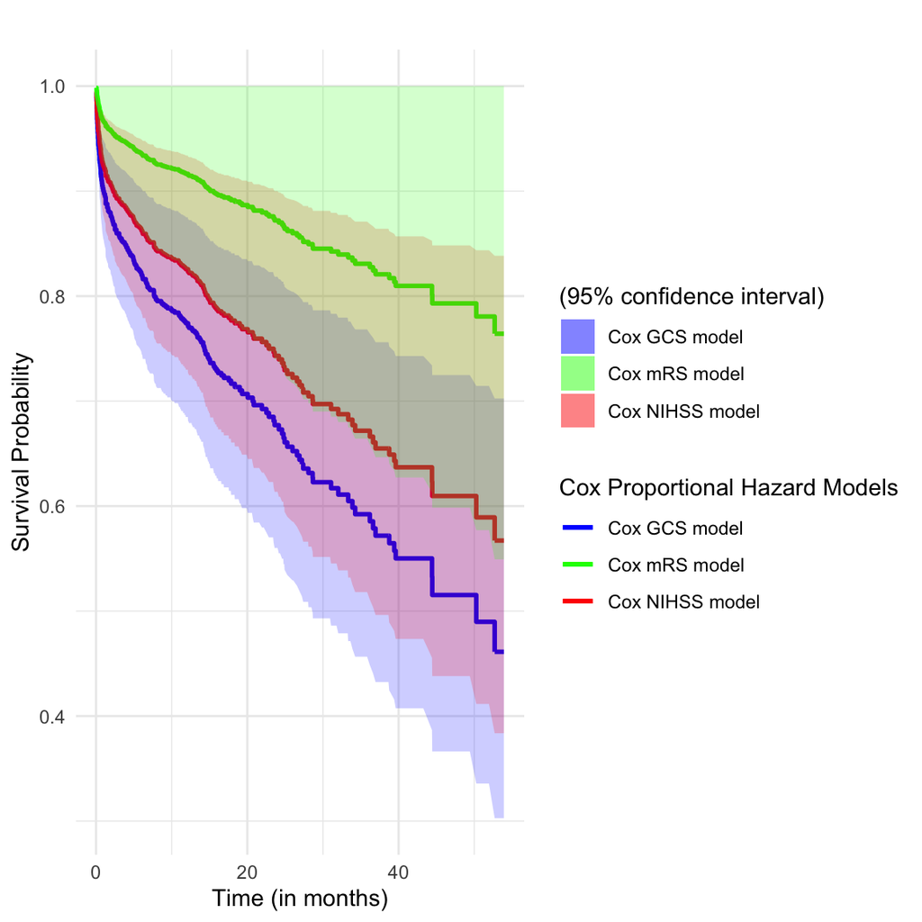

- Additionally, the Kaplan-Meier curve for the mRS model displayed a less steep decline in survival as compared to the other models.